# 常見的離散分佈

## 常見的離散分佈

- 離散均勻分佈(Discrete Uniform Distribution)
- 伯努利分佈(Bernoulli Trial)
- 二項式分佈(Binomial Distribution)
- 負二項分佈(Negative Binomial Distribution)
- 幾何分佈(Geometric Distribution)
- 超幾何分佈(Hypergeometric Distribution)
- 卜瓦松分佈(Poisson Distribution)

## 離散均勻分佈(Discrete Uniform Distribution)

- \(a, b \in \mathbb{N}\) 且 \(a \leq b\)。令\(n = b - a + 1\)
- 當\(k \in \mathbb{N}\) 且 \(a \leq k \leq b\) 時，\(P(X = k | a, b) = \frac{1}{b - a + 1}\)
- 範例：丟出均勻骰子。\(a = 1, b = 6\)
- \(E(X) = \frac{a + b}{2}\)
- \(Var(X) = \frac{(b - a + 1)^2 - 1}{12}\)

## [德國坦克問題](https://en.wikipedia.org/wiki/German_tank_problem)

- 二戰時期，德國用有順序的正整數對生產的坦克的零件作編號。一台坦克需要64個該種零件。
- 盟軍的統計學家透過統計方法估計該零件每個月的生產量，最後給出1944年二月，德軍生產了\(270\)台坦克的估計。比當時軍方的推測還要更多。
- 根據德軍的文件，當月的實際生產量是\(276\)
- 從此類似的統計方法被稱為「德軍坦克問題」

## 問題描述

- \(X\)是離散均勻分佈，以後我們記做\(X \sim unif(N)\)，\(N\)是未知的
- 我們從\(X\)中觀察到\(k\)個不重複的樣本，其中最大的值是\(m\)

### 一種統計的解決方法

- \(\hat{N} = m + \frac{m}{k} - 1\)且\(Var(\hat{N}) = \frac{(N - k) (N + 1)}{k (k + 2)}\)
  - 當 \(k << N\) 時，\(Var(\hat{N}) \approx \frac{N^2}{k^2}\)

## 伯努利分佈(Bernoulli Trial)

- 一系列離散分佈的開始
- 當我們丟一個硬幣，\(X\)代表丟出的結果：正面的機率為\(p\)，反面的機率為\(1-p\)

### 衍生的分佈

- 丟出給定的次數：二項式分佈(Binomial Distribution)
- 丟出正面的次數：幾何分佈(Geometric Distribution)
- 丟出第某次的正面次數：負二項分佈(Negative Binomial Distribution)

## 二項式分佈(Binomial Distribution)

- 最重要的離散分佈之一
- 在行銷上常常被應用

## 二項式分佈(Binomial Distribution)

- 當我們丟\(n\)個硬幣，所有的硬幣正面的機率都是\(p\)，反面的機率為\(1-p\)，而且所有的硬幣之間都是獨立的。\(X\)為正面的次數。
- 範例：
  - 連續售出\(n\)個產品，產品維修的機率一樣且彼此獨立，\(X\)是維修的產品總和
  - 連續撥放\(n\)個廣告，廣告誘發消費者購買的機率一樣，且彼此獨立，則\(X\)是最後成功誘發消費者購買產品的次數
- 如何計算\(P(X = x)\)？

## 二項式分佈(Binomial Distribution)

- 幫每個硬幣作編號：\(1, 2, 3, ..., n\)
- 挑出\(x\)個硬幣，例如：
  - 從\(4\)個硬幣中挑出\(2\)個，一共有：\(\{\{1,2\},\{1,3\},\{1,4\},\{2,3\},\{2,4\},\{3,4\}\}\)
- 我們將「從\(n\)個之中挑\(x\)個」的挑法，用\(\left(\begin{array}{c} n \\ x \end{array}\right)\)表示：

\[\left(\begin{array}{c} n \\ x \end{array}\right) = \frac{n!}{x!(n-x)!}\]

## 二項式分佈(Binomial Distribution)

- 假設挑出\(x\)個之後，剛好這\(x\)個為正面，剩下的為反面的機率為：\(p^x(1-p)^{n-x}\)
- 因此，\(P(X=n)\)的數學算式為：

\[P(X = x | n , p) = \left(\begin{array}{c} n \\ x \end{array}\right) p^x (1-p)^{n-x}\]

## 二項式分佈(Binomial Distribution)的特性

- \(E(X) = np\)

\[\begin{eqnarray} E(X) & = & \sum_{x=0}^n x P(X = x) \\ & = & \sum_{x=0}^n x \left(\begin{array}{c} n \\ x \end{array}\right) p^x (1-p)^{n-x} \\ & = & n p \left(\sum_{x=1}^n \left(\begin{array}{c} n - 1 \\ x - 1 \end{array}\right) p^{x-1} (1-p)^{n-x}\right) \\ & = & n p \end{eqnarray}\]

## 二項式分佈(Binomial Distribution)的特性

- \(Var(X) = np(1-p)\)
- 用同樣的手法計算\(E\left(X(X-1)\right)\)後，整理可得到\(Var(X)\)

## 二項式分佈(Binomial Distribution)

- 當 \(n > 9 \frac{p}{1-p}\) 且 \(n > 9 \frac{1-p}{p}\) 時可用常態分佈(Normal distribution)逼近

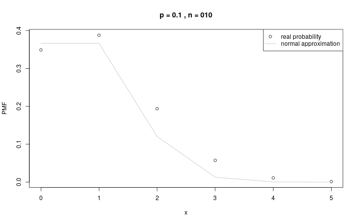

## 廣告投放操作問題

- 投放每百萬個網路廣告要花30塊錢
- 我們希望產生每個客戶的成本是0.6塊錢
- 假設老闆給我們0.3塊錢做測試。請問結果沒有點擊的機率是多少？
- 假設老闆給我們3塊錢做測試。請問結果沒有點擊的機率是多少？

## 解答

- 0.6塊錢可以買到 \(\frac{0.6}{30} 10^6 = 20000\)
- \(p = \frac{1}{20000}\)

### 預算0.3 塊錢

- \(n = \frac{0.3}{30} 10^6 = 10000\)
- \(P(X = 0 | 10000, \frac{1}{20000}) = (1 - \frac{1}{20000})^{10000} = 0.6065\)

### 預算3 塊錢

- \(n = \frac{3}{30} 10^6 = 100000\)
- \(P(X = 0 | 100000, \frac{1}{20000}) = (1 - \frac{1}{20000})^{100000} = 0.0067\)

## 負二項分佈(Negative Binomial Distribution)

- 丟一個硬幣，硬幣出現正面的機率為\(p\)。我們會一直丟，直到剛好有\(r\)次出現正面。總共丟的次數為隨機變數\(X\)，\(X\)的分佈稱為負二項式分佈。
- \(X = x\) 的機率可以從二項式分佈導出：
  - 前面\(x-1\)次剛好有\(r-1\)次正面，發生的機率是：\(\left(\begin{array}{c}x - 1 \\ r - 1\end{array}\right) p^{r-1} (1-p)^{x-r}\)
  - 第\(x\)次剛好是正面的機率是\(p\)
- 所以：

\[P(X = x | r, p) = \left(\begin{array}{c}x - 1 \\ r - 1\end{array}\right) p^r (1-p)^{x - r}\]

- \(x = r, r + 1, ...\)

## 負二項分佈(Negative Binomial Distribution)

- 有時候會用以下的方式定義負二項分佈(Negative Binomial Distribution)：
  - 隨機變數\(Y\)是在丟出\(r\)次正面之前的反面的次數
- 統計上，\(Y = X - r\)，兩者的分佈等價：

\[P(Y = y) = P(X - r = y) = P(X = y + r) = \left(\begin{array}{c}y + r - 1 \\ r - 1\end{array}\right) p^r (1-p)^{y}\]

- \(y = 0, 1, ...\)

### 期望值與變異數

- \(E(Y) = r \frac{1 - p}{p} \rightarrow E(X) = E(Y) + r = \frac{r}{p}\)
- \(Var(Y) = \frac{r(1-p)}{p^2} = Var(X)\)

## 負二項分佈(Negative Binomial Distribution)

- \(r\)大的時候可以用常態分佈逼近

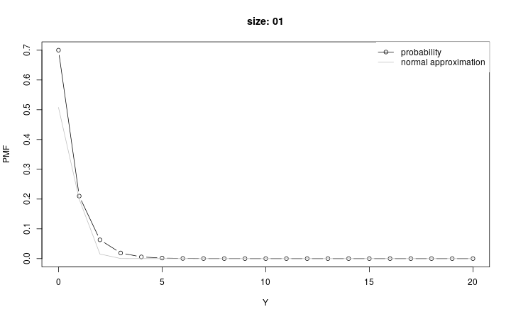

## 範例

- 如果一個人是白子的機率是 0.6%
- 有研究者要訪問10個白子。請問他需要搜尋的人數的期望值為？
  - \(r \frac{1-p}{p} = 10 \frac{1 - 0.006}{0.006} = 1656.667\)
- 訪問會在搜尋3000人之前結束的機率？
  - 可以套用切比雪夫不等式做估計：\(Pr(|X - E(X)| \geq b) \leq \frac{Var(X)}{b^2}\)
    - 可以得出機率大於\(0.8469912\)
  - 用Normal Approximation: \(0.9947131\)
  - 直接用統計軟體算：\(0.98533\)

## 幾何分佈(Geometric Distribution)

- 連續投擲一個正面機率為\(p\)的硬幣，\(X\)為丟到出現第一次正面所需的次數

\[P(X = x | p) = \left(\begin{array}{c}x - 1 \\ 0\end{array}\right) p (1-p)^{x - 1} = p(1 - p)^{x - 1}\]

- \(X\) 為 負二項分佈(Negative Binomial Distribution)中\(r=1\)的特例
- \(E(X) = \frac{1}{p}\)
- \(Var(X) = \frac{1-p}{p^2}\)

## 幾何分佈的特性：無記憶性

- 如\(s > t\)，且\(X\)是幾何分佈(Geometric Distribution)，則：

\[P(X > s | X > t) = P(X > s - t)\]

- \(r\)個獨立的幾何分佈的隨機變數\(X \sim Geometric(p)\)的和，稱為獨立變數\(Y\)
  - \(Y\)是負二項分佈，且參數為\(r\)與\(p\)

## 超幾何分佈(Hypergeometric Distribution)

- 工廠生產了一\(N\)個產品，其中有\(M\)個是不良品
- 我們一次抽\(K\)個出來做檢驗，\(X\)代表驗出不良品的數量
- \(X \sim HyperGeometric(N, M, K)\)

\[P(X = x | N, M, K) = \frac{\left(\begin{array}{c} M \\ x \end{array}\right) \left(\begin{array}{c} N - M \\ K - x \end{array}\right)}{\left(\begin{array}{c} N \\ K \end{array}\right)}\]

- \(E(X) = \frac{KM}{N}\)
- \(Var(X) = \frac{KM(N-M)(N-K)}{N^2(N-1)}\)

## 超幾何分佈(Hypergeometric Distribution)

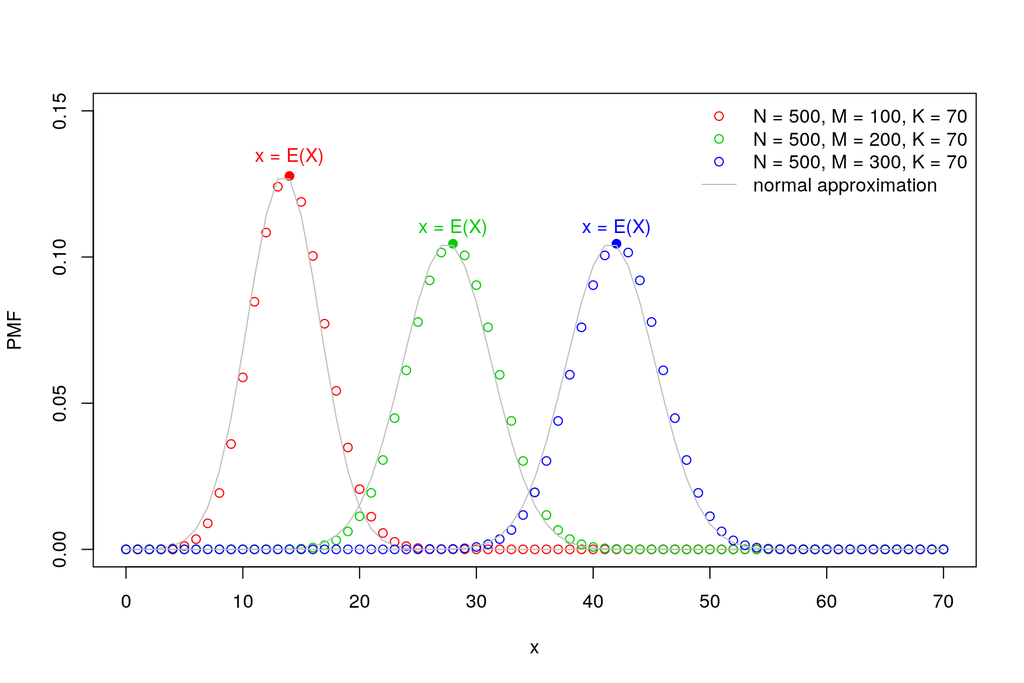

## 檢定驗票

- 如果有100個開票所，其中有5個會有問題
- 我們隨機挑\(K\)個投開票所監票，最後監票都沒回報問題的機率是多少？

\[P(X = 0 | 100, 5, K) = \frac{\left(\begin{array}{c} 5 \\ 0 \end{array}\right) \left(\begin{array}{c} 95 \\ K \end{array}\right)}{\left(\begin{array}{c} 100 \\ K \end{array}\right)}\]

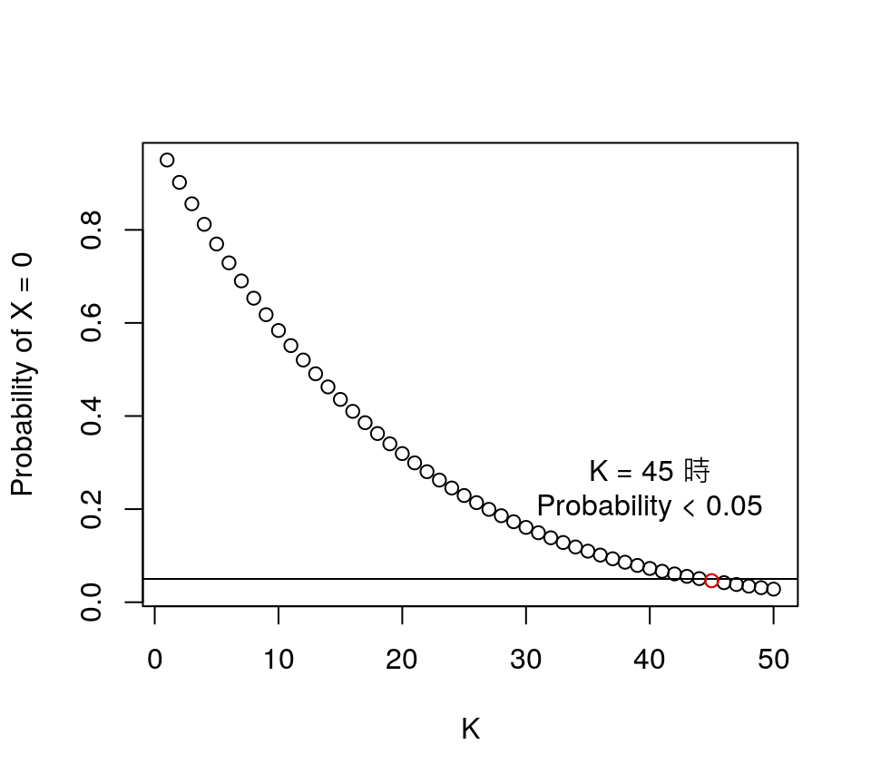

## 比較

|  | 取後放回 | 取後不放回 |
| --- | --- | --- |
| 給定抽取的次數 | 二項式分佈 | 超幾何分佈 |
| 給定失敗（成功）的次數 | 負二項式分佈 | 負超幾何分佈* |

## 卜瓦松分佈(Poisson Distribution)

### 為什麼會發展卜瓦松分佈(Poisson Distribution)？

- 要用這個分佈描述「固定時間之內」的事件發生次數：
  - 一個小時內，有多少地震發生
  - 開店的一小時內，有多少顧客光臨

### 卜瓦松分佈(Poisson Distribution)的數學定義：

\[P(X = x | \lambda) = \frac{e^{-\lambda} \lambda^x}{x!}\]

- \(x = 0, 1, ...\)

## 卜瓦松分佈(Poisson Distribution)

### \(\lambda\)是什麼？

- 讓我們來說個故事…

## 嘗試用二項式分佈來解問題

- 假設我知道一天賣出了\(30\)件產品
- 我們從早上10點賣到晚上8點，一共賣了\(10\)個小時
  - 平均每個小時賣\(3\)件產品
  - 沒有辦法用二項式分布處理…（為什麼？）
- 一共賣了\(10 \times 60 = 600\)分鐘，平均每分鐘賣\(30 / 600 = 0.05\)件產品
  - 可以用\(p = 0.05\)與\(n = 60\)來描述每個小時賣出的產品量
  - 那如果只看一分鐘，而我們希望賣出不止一件呢（為什麼沒辦法用二項式分佈？）
- 一共賣了\(10 \times 60 \times 60 = 36000\)分鐘，平均每秒賣\(30 / 36000\)件產品
  - 可以用\(p = 30 / 36000\)、\(n = 3600\)來描述每個小時賣出的產品量
  - 可以用\(p = 30 / 36000\)、\(n = 60\)來描述每分鐘賣出的產品量

## 可以一直切下去嗎？

- 我們不停的變動\(n\)與\(p\)：
  - 每當\(n\)變多，\(p\)就等比例的變小，所以\(np\)是常數（也是期望值）
  - \(\lambda\)就代表這個常數

### 那 \(P(X = x | \lambda) = \frac{e^{-\lambda} \lambda^x}{x!}\) 怎麼來的？

\[\tiny{\begin{eqnarray} \lim_{n \rightarrow \infty} P(X = x | n , \frac{\lambda}{n}) &=& \lim_{n \rightarrow \infty} \left(\begin{array}{c} n \\ x \end{array}\right) \left(\frac{\lambda}{n}\right)^x \left(\frac{n - \lambda}{n}\right)^{n-x} \\ & = & \lim_{n \rightarrow \infty} \frac{n!}{k!(n-k)!} \frac{\lambda^x}{n^x} \left(\frac{n - \lambda}{n}\right)^n \left(\frac{n - \lambda}{n}\right)^{-x} \end{eqnarray}}\]

\[\tiny{\begin{eqnarray} \lim_{n \rightarrow \infty} \left(\frac{n - \lambda}{n}\right)^n &=& e^{-\lambda} \\ \lim_{n \rightarrow \infty} \left(\frac{n - \lambda}{n}\right)^{-x} &=& 1 \end{eqnarray}}\]

\[\tiny{\begin{eqnarray} \lim_{n \rightarrow \infty} \frac{n!}{x!(n-x)!} \frac{\lambda^x}{n^x} &=& \lim_{n \rightarrow \infty} \frac{n!}{n^x(n-x)!} \frac{\lambda^x}{x!} \\ \lim_{n \rightarrow \infty} \frac{n!}{n^x(n-x)!} & = & \frac{n}{n} \times \frac{n-1}{n} \times \frac{n-2}{n} \times ... \times \frac{n-x+1}{n} = 1 \end{eqnarray}}\]

## \(\lambda\)越大，卜瓦松分佈就越接近常態分佈

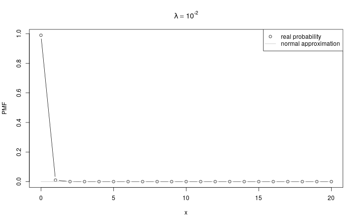

## 卜瓦松分佈(Poisson Distribution)的特性

- 事件發生的**比率**(\(\lambda\))不會隨著時間改變

## 範例一（延續剛剛的例子）

- 假設我知道一天賣出了\(30\)件產品
- 我們從早上10點賣到晚上8點，一共賣了\(10\)個小時
- 用卜瓦松分佈(Poisson Distribution)描述一個小時可以賣出的產品數量的機率：
- 一個小時平均賣出\(3\)件產品，所以\(\lambda = 3\)
- 沒有賣出產品的機率是\(\frac{3^0 e^{-3}}{0!} = 0.0497871\)
- 賣出一件產品的機率是\(\frac{3^1 e^{-3}}{1!} = 0.1493612\)

## 範例二

- 用卜瓦松分佈(Poisson Distribution)描述半小時可以賣出的產品數量的機率：
- 半個小時平均賣出\(1.5\)件產品，所以\(\lambda = 1.5\)
- 沒有賣出產品的機率是\(\frac{1.5^0 e^{-1.5}}{0!} = 0.2231302\)
- 賣出一件產品的機率是\(\frac{1.5^1 e^{-1.5}}{1!} = 0.3346952\)

## 卜瓦松分佈(Poisson Distribution)的特性

- 如果\(X_1\)代表 10:00 ~ 10:30 的賣出的數量的隨機變數，且\(X_1 \sim Poisson(\lambda_1)\)
- 如果\(X_2\)代表 10:30 ~ 11:00 的賣出的數量的隨機變數，且\(X_2 \sim Poisson(\lambda_2)\)
- 則若\(X = X_1 + X_2\)代表 10:00 ~ 11:00 的賣出的數量的隨機變數，且 \(X_1\) 與 \(X_2\) 獨立，則 \(X \sim Poisson(\lambda_1 + \lambda_2)\)

## 範例三

- 上述範例中，一個小時賣出0件的機率是半個小時賣出0件的機率的平方
- \(P(X = 0 | \lambda = 3) = \frac{3^0 e^{-3}}{0!} = e^{-3} = (e^{-1.5})^2 = P(X = 0 | \lambda = 1.5)^2\)